# Estudo Qualitativo NPS

## Critérios de inclusão

O estudo a seguir se trata apenas das submissões de usuários que atendem a pelo menos um desses critérios:

- ser cliente do CS ou
- ter feito pelo menos uma venda nos últimos 12 meses.

A pesquisa foi realizada com 17962 usuários distintos, dos quais 17261 atendem a pelo menos um dos critérios, conforme o gráfico:

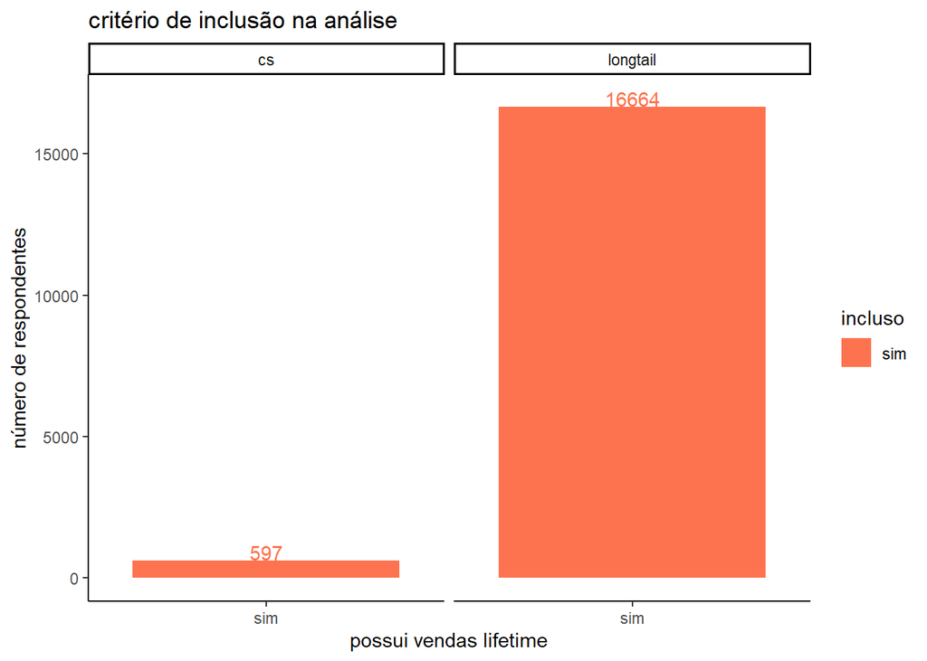

## Bechmarks

O cálculo do NPS (*Net Promoter Score*) é feito da seguinte maneira:

$NPS = \text{Proporcao}(promotores) - \text{Proporcao}(detratores)$

Esse valor pode ser lido como o “saldo” de promotores da plataforma, e pode variar de -100 a 100. Algumas médias comparativas para o valor do NPS são:

1. A média da indústria.
2. A média do país ou região.
3. A média do canal de pesquisa.
4. Os valores anteriores de NPS da própria pesquisa da Hotmart.

Neste estudo, vamos focar nos pontos 1 e 4. Os pontos 2 e 3 são possíveis desenvolvimentos futuros do estudo. A média de NPS por indústria, por exemplo, é diferente entre países. Clientes de culturas diferentes atribuem notas diferentes mesmo igualmente satisfeitos, etc. Por isso, o ponto 4 é a referência mais objetiva possível.

### Indústria

O gráfico a seguir mostra o NPS médio dentro de diferentes indústrias, além de uma barra com referências gerais para as notas. O NPS 2021 / 1 da Hotmart também aparece no gráfico, destacado com um fundo cinza:

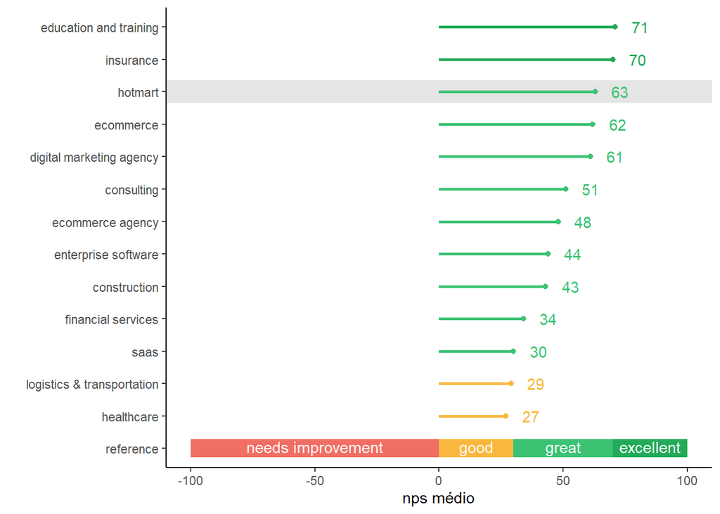

### Evolução

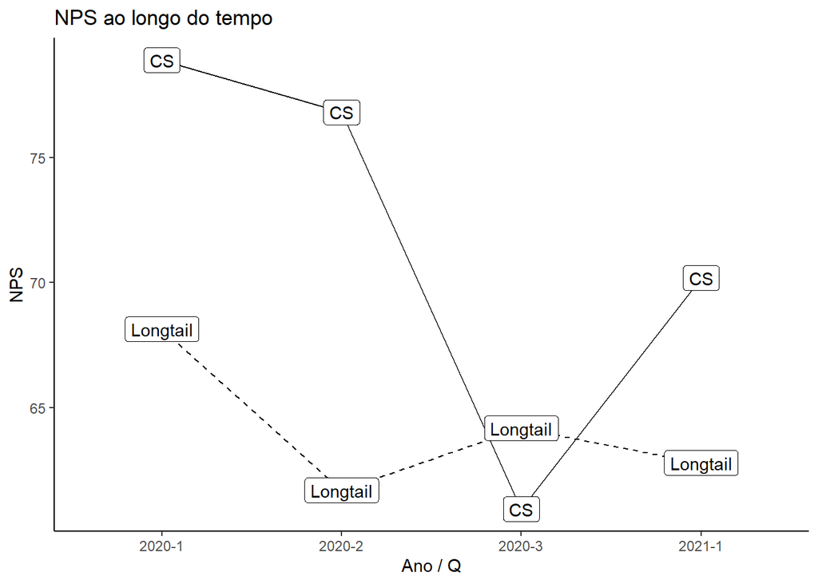

No gráfico abaixo, podemos ver como cada estágio evoluiu em termos de classes (detrator, neutro ou promotor). As barras verticais indicam intervalos de confiança, que podem ser usados para verificar se a diferença em proporções de um Q para outro é significativa.

> Como interpretar os intervalos: Se o ponto do Q atual está fora do intervalo do Q anterior, significa que a proporção da classe no estágio observado foi significativamente diferente entre os Qs.

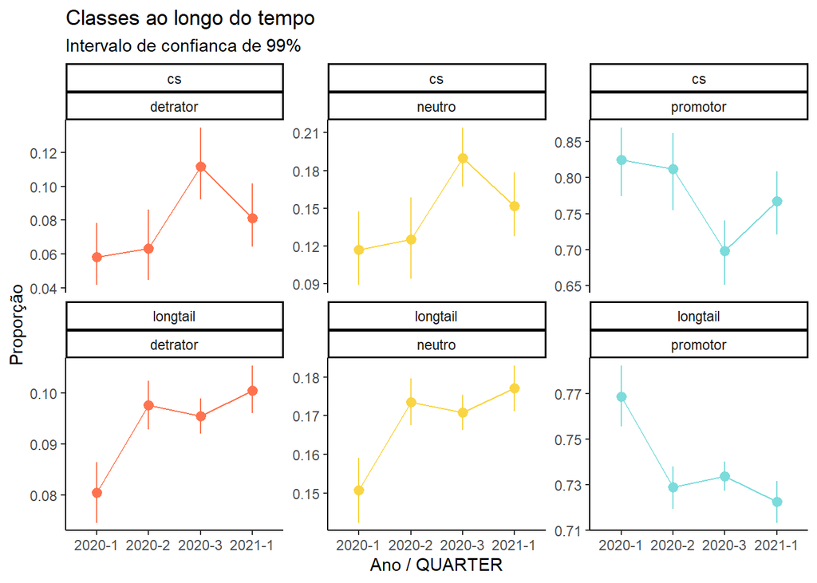

Uma outra maneira de comparar os Qs é no nível individual. Existem 5207 usuários comuns às pesquisas 2021 / 0 e 2021 / 1. Podemos verificars os percentuais de conversões entre esses usuários na tabela a seguir, onde a linha é a classe anterior e a coluna é a classe atual. Conversões boas estão em verde, ruins em vermelho, e manutenções em amarelo:

### CS

Número de conversões: 352.

| classe anterior | detrator | neutro | promotor |
| --- | --- | --- | --- |
| detrator | 1.99 | 1.14 | 2.56 |
| neutro | 2.84 | 10.23 | 12.5 |
| promotor | 1.14 | 6.25 | 61.36 |

A tabela abaixo mostra alguns exemplos de razão para cada tipo de conversão:

| anterior | atual | razão |
| --- | --- | --- |
| promotor | neutro | apesar de ser um dos maiores cases de volume de vendas da Hotmart, notei que nos últimos meses a qualidade de atendimento que recebemos tem piorado muito a ponto de começarmos a olhar com mais atenção… |
| promotor | neutro | Ontem tentei comprar com o saldo da Hotmart e foi impossível, a plataforma dizia que mandava um token para meu e-mail e o mesmo nunca chegava. Então optei pelo Pix, e ao tentar pagá-lo, recebia a mens… |
| promotor | neutro | Tem várias soluções boas, mas existem algumas saídas que poderiam ser aplicadas. Por exemplo, permitir a duplicação de um conteúdo em um módulo. |
| promotor | detrator | Falta de comunicação para ajudar a resolver problemas . Hotmart por vezes é bem complicada , já tive muitos problemas que poderiam ser resolvidos de maneiras rápidas e direta se pudesse ter um telefon… |
| promotor | detrator | Nós estamos com diversos problemas deste o princípio da nossa conta. 1 - Nós tivemos produtos reavaliados e suspensos sem qualquer comunicação prévia no dia 29 de DEZEMBRO. 2 - Até o presente momento … |
| neutro | promotor | Hotmart é excelente. Tudo funciona, a plataforma é intuitiva, o atendimento é bom. Tudo 100%. O único revés é que, à medida que o negócio começa a ganhar corpo, as taxas começam a pesar. |
| neutro | promotor | Para quem está começando a vender online é ótimo. Depois de um certo crescimento é mais válido desenvolver o sistema próprio de assinaturas pois a taxa que a Hotmart cobra sobre as vendas fica muito r… |
| neutro | promotor | Porque acho a plataforma inteligente, intuitiva e ela esta sempre em evolução pra acompanhar e se antecipar naquilo que preciso. Sou apaixonada na plataform pq dificilmente consigo usar coisas de tecn… |
| neutro | detrator | Aplicativo Sparkle deixa muito a desejar! Alunos reclamando de dificuldades para acessar, dificuldades para fazer funcionar o Chromecast, tem dias que funciona tem dias que não. Já abrimos diversos ch… |
| neutro | detrator | Excelente empresa, mas ainda tem alguns pontos a melhorar. Acredito muito no projeto. PS: A insistência de preenchimento do questionário são bem chatos caso eu não responda na hora.. |
| neutro | detrator | O serviço concorrente dá a opção de antecipar 95% do saldo, a uma taxa menor, com um serviço igual ou superior ao hotmart. Não estou vendo muito sentido em continuar, apesar do carinho que tenho pelo … |
| detrator | promotor | A Plataforma tem as melhores ferramentas sem dúvidas, porém, ainda peca bastante na comunicação com o Cliente principalmente com assuntos relacionados a suporte. |
| detrator | neutro | Porque vejo que há pontos que a Hotmart ainda precisa melhorar bastante. Especialmente no que diz respeito ao Hotmart Club… Há anos que é tudo igual! Tenho diversas sugestões de como evoluir para que … |

### Longtail

Número de usuários: 4855.

| classe anterior | detrator | neutro | promotor |
| --- | --- | --- | --- |
| detrator | 3.77 | 1.94 | 1.4 |
| neutro | 2.45 | 7.23 | 7.04 |
| promotor | 1.96 | 9.23 | 64.98 |

A tabela abaixo mostra alguns exemplos de razão para cada tipo de conversão:

| anterior | atual | razão |
| --- | --- | --- |
| promotor | neutro | Afiliação global deveria existir para qualquer produto. Tem produtor usando produto barato para atrair afiliados que gasta uma grana, enche o pixel da pagina. Ai ele lança um produto oculto, ou com af… |
| promotor | neutro | Dificuldade de Colocar a forma de pagamento, no momento estou tendo problema para receber as vendas do meu curso, estou focado na produção de conteúdo, e correr atrás para resolver esse assunto nesse … |
| promotor | neutro | Pq não tem Antecipação de Saque, e isso Prejudica dimais quem trabalha com Tráfego Pago, e pq eu acho que as Comissões deveriam ser Liberadas logo após os 07 dias da garantia, pra gente poder investir… |
| promotor | detrator | A Plataforma não incluiu a tag ’início do curso" para incluir no certificado, gerando assim um trabalho manual enorme por parte da equipe de atendimento. |
| promotor | detrator | Eu acho vocês incríveis, a melhor plataforma sem sombra de dúvida, porém uma coisa que me incomoda demais é vocês reterem o valor por 30 dias. Que tal criar novos mecanismos para os infoprodutores pod… |
| promotor | detrator | Existe muito cursos bons, mas tem muuuuitos que são uma porcaria. Outra coisa: Eu não acho justo o produtor colocar tempo para liberar os modulos. Comprei um curso e depois dos 7 dias foi liberado o s… |
| neutro | promotor | Me serve bem. Gostaria apenas de um atendimento mais rápido e de alguma funcionalidades, como usar o mesmo conteúdo em cursos diferentes sem a necessidade de fazer nova configuração. Também acredito q… |
| neutro | promotor | Por mais que eu ainda não tenho resultados incríveis, eu sei que nessa plataforma é sim possível alcançar. E por isso sempre indico ainda a hotmart. Os concorrentes ainda estão caminhando. |
| neutro | promotor | Porque é do Erico, e porque me atende muito bem apesar de termos tido alguns problemas, e também a porcentagem é maior que outras plataformas. |
| neutro | detrator | De acordo com o crescimento da plataforma o atendimento tem ficado demorado, já foio mais rápido e eficiente. A falta de integração com plataformas externas também atrapalha muito, a eduzz integra com… |
| neutro | detrator | Integração extensões hotmart é péssima, área de membros confusa para o usuário, maior taxa do mercado, não tem suporte via chat, não tem suporte via telefone, enquanto outras plataformas oferecem chat… |
| neutro | detrator | Porque ao inves de facilitar está complicando Ja faz uma semana que enrola a aprovaçãode um produto que todo mes eu solto.Solto 12 por ano. Vaik ser esse inferno? |
| detrator | promotor | A Hotmart salvou minha vida! A mais ou menos um ano e meio atrás eu não tinha o quer comer, hoje quase um ano e meio depois, tenho tudo oque eu sempre sonhei, ja faturei mais de 2,5 milhões brutos na … |
| detrator | promotor | Porque no que diz respeito à hospedagem dos meus cursos, nunca travou e sempre entregou o conteúdo para os alunos. Atendeu à proposta muito bem. |
| detrator | promotor | Pq a plataforma em geral é melhor que as outras, minha nota foi fazendo uma comparação com Eduzz e Monetizze e eu não poderia dar a mesma nota para as outras, entendo que a Hotmart apesar das taxas ma… |
| detrator | neutro | Cancelamento automático de afiliação por falta de vendas durante um período prejudica muito quem trabalha com tráfego orgânico. Devido a essa opção (restriçāo) estou focando em outras plataformas. |
| detrator | neutro | Porque, por pressão externa, vocês excluíram alguns cursos da plataforma por conta de “viés político”, no entanto, há vários cursos aqui justamente com esse tipo de conteúdo e esses vocês não excluíra… |
| detrator | neutro | Vocês tem q melhorar o suporte urgentemente, não ter um chat é inaceitável… Não me venham com a história de que vcs tem mais de 10.000 tickets por dia, que é impossível montar tele-atendimento para es… |

## Pesquisa 2021 / 1

As submissões dos questionários da pesquisa 2021 / 1 aconteceram entre 2021-01-31 e 2021-02-15. O gráfico a seguir mostra o número de respostas por dia e as proporções das classes entre as respostas:

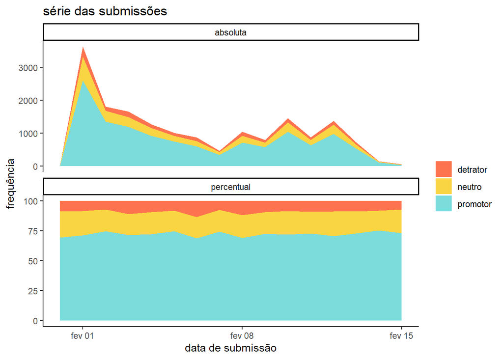

### Validação de Hipóteses

Para cada hipótese testada nessa seção, foram produzidas duas visualizações.

A primeira mostra as proporções de classes em cada grupo. Essa primeira visualização não é um teste, mas sim uma descrição do banco de dados para auxiliar na interpretação do teste.

A segunda visualização mostra a probabilidade de indivíduos dentro de um determinado grupo pertencerem a uma determinada classe, segundo o modelo:

$\text{Probabilidade}(classe) = \text{efeito}(estagio) + \text{efeito}(segmentacao)$

Nesse modelo, a probabilidade de um usuário ser promotor, neutro ou detrator é proporcional à combinação dos efeitos de suas características. Assim, podemos identificar os efeitos isolados de cada característica.

1. **CS vs Longtail**

A distribuição das classes promotor (nota >= 9), neutro (nota 7 ou 8) e detrator (nota <= 6) é diferente entre os estágios CS e longtail.

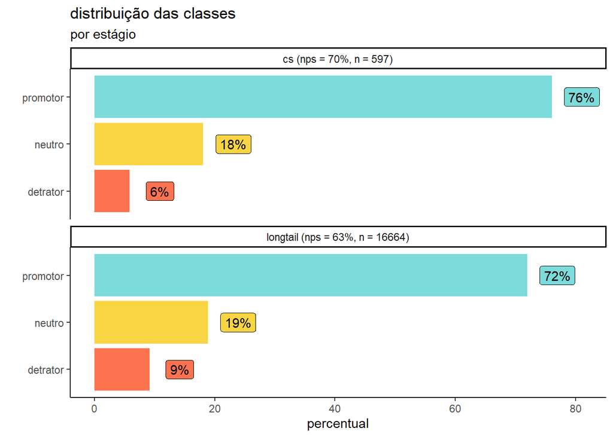

> Como interpretar os intervalos: Se o ponto de um fator está fora do intervalo de outro fator, significa que a probabilidade de encontrar a classe observada dentro é significativamente diferente entre os fatores. Intervalos mais amplos significam maior incerteza sobre as estimativas.

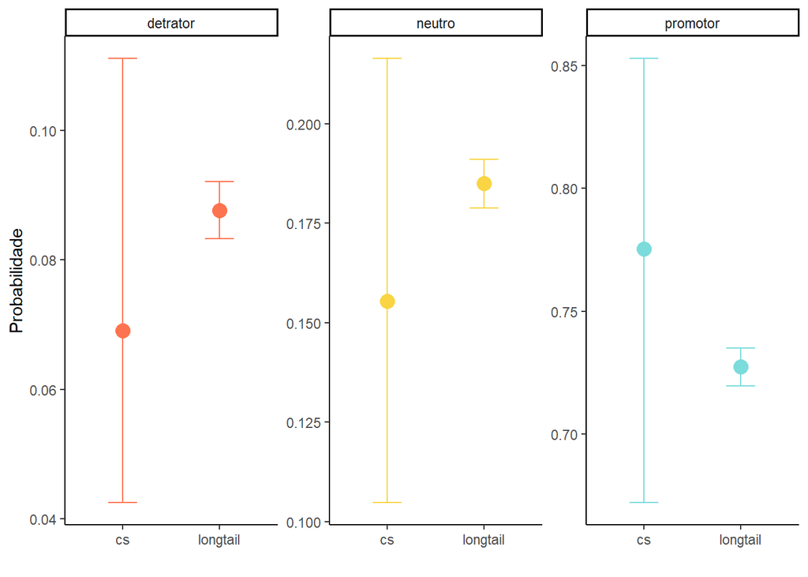

2. **Segmentação**

A distribuição das classes por segmento está no gráfico abaixo:

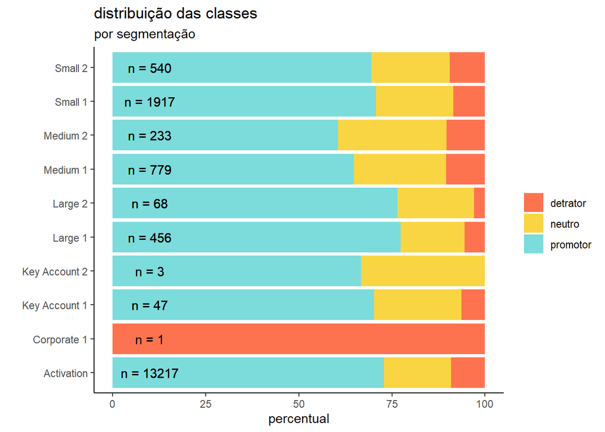

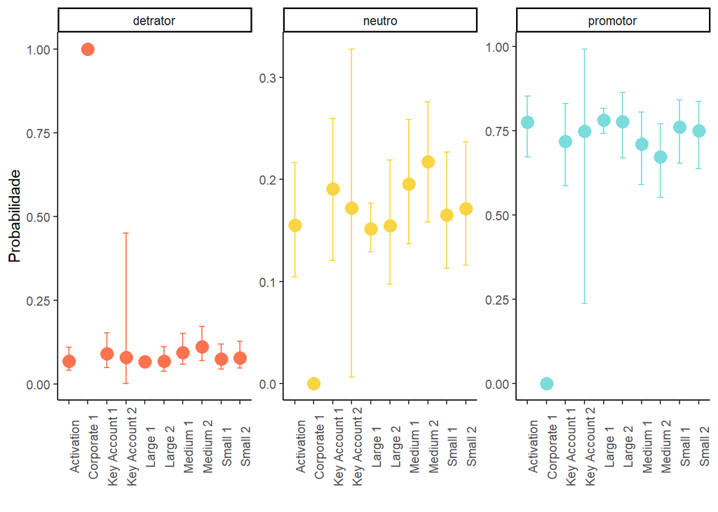

A tabela abaixo mostra todas as razões de Key Accounts neutras ou detratoras. É interessante notar que a nota 8, apesar de classificar um usuário como neutro, tem um sentido positivo para alguns usuários.

| nota | classe | segmentação | razão |
| --- | --- | --- | --- |
| 2 | detrator | Key Account 1 | Serviço vem piorando muito de uns anos pra cá |
| 5 | detrator | Key Account 1 | Dois pontos: primeiro que o gerente de conta nunca responde aos chamados de ajuda para resolver duvidas, praticamente somos ignorados, e leve em conta que somos uma conta black com milhões em vendas. … |
| 6 | detrator | Key Account 1 | Apesar de algumas evoluções com o Sistema, ainda há coisas em desenvolvimento e a melhorar. Há algumas questões latentes, como a falta de uma ferramenta para o envio de acesso automático para o aluno … |
| 7 | neutro | Key Account 1 | Em relação a plataforma vemos que ainda podem melhorar a parte de relatórios dos clientes, a área de membros ser integrada qdo o cliente compra mais de 1 produto nosso não precisar fazer acessos difer… |
| 7 | neutro | Key Account 1 | já dei resposta anteriormente. Quero só adicionar algo sobre minha gerente de contas |
| 7 | neutro | Key Account 1 | Taxa alta comparada a quem tem faturamento menor |
| 7 | neutro | Key Account 1 | os filtros para levantamento de dados vem “sujos”com dados das recorrência, para saber por exemplo os dados das vendas, sem a ajuda da nossa gerente de contas. Ela é fantástica, sempre disposta e disp… |
| 7 | neutro | Key Account 2 | Parece que cresceu muito. e esta mais dificil de deixar a maquina rodar direito. |
| 8 | neutro | Key Account 1 | Existem algumas features que precisam sair do roadmap o quanto antes. Como cupom personalizado, conclusão automática progressiva de aula no club e gift card (ou outra forma de presentear alguém). |
| 8 | neutro | Key Account 1 | Serviço muito bom, mas ainda ocorrem algumas mudanças que impactam no negócio com pouquissimo aviso |
| 8 | neutro | Key Account 1 | Porque a ferramenta nos atende como produtor mas ainda tem a evoluir em questões de dados financeiros. |
| 8 | neutro | Key Account 1 | Porque precisamos de melhorias no sistema. Parcelamento no boleto. Cupom desconto em assinaturas, segurança de descontos vinculados a compra, onde o aluno só consiga usar o desconto uma vez. Cupom de … |
| 8 | neutro | Key Account 1 | Pelo funcionamento da plataforma e das taxas cobradas |
| 8 | neutro | Key Account 1 | Apesar de o hotmart ser uma plataforma super completa sempre tem algo a melhorar |
| 8 | neutro | Key Account 1 | apesar de ser um dos maiores cases de volume de vendas da Hotmart, notei que nos últimos meses a qualidade de atendimento que recebemos tem piorado muito a ponto de começarmos a olhar com mais atenção… |

### Análise de texto

Ao visualizarmos as top 7 palavras dentro de cada estágio, podemos observar:

- Algumas palavras surgem exclusivamente em determinados estágios.
- Algumas palavras são mais positivas e outras mais negativas.
- *Taxa* é uma palavra negativa em ambos os estágios.

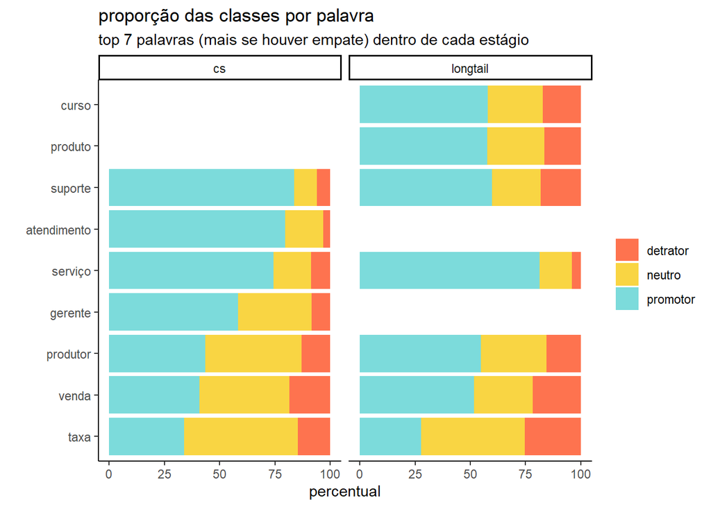

O top 5 palavras por estágio e classe revela comportamentos distintos entre os blocos (combinações entre estágio e classe, ex: *cs-promotor*).

> Palavras seguidas por parêntese aparecem em mais de um bloco. Palavras sem parêntese são exclusivas a um bloco.

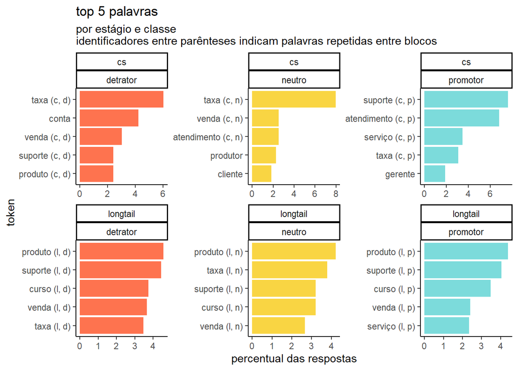

Para cada combinação entre estágio, classe e palavra, podemos pegar alguns exemplos de razões dadas pelos usuários:

### CS

| classe | token | razão |
| --- | --- | --- |
| detrator | produto (c, d) | Nós estamos com diversos problemas deste o princípio da nossa conta. 1 - Nós tivemos produtos reavaliados e suspensos sem qualquer comunicação prévia no dia 29 de DEZEMBRO. 2 - Até o presente momento … |
| detrator | suporte (c, d) | Simplesmente, pois temos um dificuldade em subir módulos de um produto para outro, sem falar que o numero de cartões recusados (vendas canceladas) é imenso. Em um lançamento eu tive 45 vendas cancelad… |
| detrator | venda (c, d) | É a 5º vez que preencho esse mesmo formulário nos últimos 10 dias e continuam solicitando. A taxa é cara caso eu não use afiliados. Meu meio alternativo de pagamento (com o qual eu faço 1/3 das vendas… |
| detrator | conta | Dois pontos: primeiro que o gerente de conta nunca responde aos chamados de ajuda para resolver duvidas, praticamente somos ignorados, e leve em conta que somos uma conta black com milhões em vendas. … |
| detrator | taxa (c, d) | O serviço concorrente dá a opção de antecipar 95% do saldo, a uma taxa menor, com um serviço igual ou superior ao hotmart. Não estou vendo muito sentido em continuar, apesar do carinho que tenho pelo … |
| neutro | cliente | Porque eu já uso a plataforma há 8 anos e confio no trabalho e na responsabilidade da empresa. Só acho as taxas muito altas e o serviço de atendimento ao cliente deixa a desejar em alguns momentos. |
| neutro | produtor | A Hotmart é a melhor experiência do usuário enquanto consumidor de conteúdo, eu mesma amo usar o sparkle para consumir meus cursos. No entanto, para o produtor, a questão financeira ainda é algo a ser… |
| neutro | atendimento (c, n) | Em relação a plataforma vemos que ainda podem melhorar a parte de relatórios dos clientes, a área de membros ser integrada qdo o cliente compra mais de 1 produto nosso não precisar fazer acessos difer… |
| neutro | venda (c, n) | Acredito que a taxa é alta, tivemos muitos problemas com confirmação de pagamento e acesso à plataforma (nossa venda foi expressiva) isso atrapalhou a dinâmica de vendas porque o pós compra ficou prej… |
| neutro | taxa (c, n) | Em relação a plataforma vemos que ainda podem melhorar a parte de relatórios dos clientes, a área de membros ser integrada qdo o cliente compra mais de 1 produto nosso não precisar fazer acessos difer… |
| promotor | gerente | Estou muito satisfeito. Só precisa ser mais competitiva na taxa. Certa vez um gerente abaixou um pouco a minha taxa e me prometeu abaixar um pouco mais quando eu atingisse determinado valor de faturam… |
| promotor | taxa (c, p) | Acho ela boa, gosto do atendimento que tenho hoje, gosto do sparkle, e sei que é uma empresa séria. Por outro lado sei que afiliado pequeno ainda sem atendimento, acho as taxas alta, acho que tem prob… |
| promotor | serviço (c, p) | Pelo que venho experimentando dos serviços da Hotmart, estou muito satisfeito tanto com a qualidade dos serviços quanto com o suporte. |
| promotor | atendimento (c, p) | Por que o atendimento é os recursos é sensacional não tem o que reclamar |
| promotor | suporte (c, p) | Por que a plataforma atende todas as nossas necessidades atuais. O suporte é rápido e eficiente. |

### Longtail

| classe | token | razão |
| --- | --- | --- |
| detrator | taxa (l, d) | Integração extensões hotmart é péssima, área de membros confusa para o usuário, maior taxa do mercado, não tem suporte via chat, não tem suporte via telefone, enquanto outras plataformas oferecem chat… |
| detrator | venda (l, d) | Pois sou Produtor e coloquei meu produto na plataforma há um tempo e para que eu possa realizar mais vendas tenho que recorrer ao tráfego pago. Os afiliados não são esforçados. E o mercado da platafor… |
| detrator | curso (l, d) | O serviço em si é bom, mas não tem boas soluções para assinaturas recorrentes. A área de membros é boa para cursos, mas não para revistas, que era o que precisávamos mais. Não é que seja ruim, é que p… |
| detrator | suporte (l, d) | Sou jovem, tenho uma mini- empresa, Estudei Medicina na Alemanha, sou formada em terapia biográfica entre muitos outros diplomas, trabalho com terapias ONLINE antes mesmo da quarentena e tive ENORME d… |
| detrator | produto (l, d) | A Plataforma urgentemente precisa ser mais dinamica/agil/interativa quando se tem a necessidade de acessar os produtos comprados, sempre abrindo abas e mais abas alias infindaveis abas. Se ao clicar n… |
| neutro | venda (l, n) | O Hotmart tem sido uma ferramenta que facilita demais a distribuição do meu produto, tanto no cadastro dele no Hotmart Club, quanto na venda; no entanto, penso que poderia reduzir um pouco os custos q… |
| neutro | curso (l, n) | Porque a minha experiência está sendo boa mas poderia melhorar, por exemplo o a permissão para saque poderia ser a partir da primeira venda independente do valor. Mas quanto aos cursos que comprei até… |
| neutro | suporte (l, n) | Porque precisa diminuir a taxa de vendas. Vou fazer o lançamento do meu curso agora dia 15/02 e estou pensando seriamente se coloco o produto na hotmart ou não. E além disso, o suporte por email acho … |
| neutro | taxa (l, n) | plataforma excelente, porém as taxas para produtores é alta. |
| neutro | produto (l, n) | Principalmente pela incapacidade de afiliados estrangeiros afiliarem-se à produtos cadastrados no Brasil. Isso afecta bastante aos afiliados estrangeiros profissionais. Falo com tanta autoridade poque… |
| promotor | serviço (l, p) | Ótima plataforma, em relação ao sistema (software) não há considerações a fazer, só não vejo absolutamente nenhuma necessidade em cobrar R$ 2,50 ou próximo disso para um serviço de “proteção de vídeo”… |
| promotor | venda (l, p) | Porque ainda faltam ajustes por exemplo, eu sou psicologa e ofereco o servico de atendimento online, a plataforma ajuda bastante o agrndamento, porem falta informacoes de como serei avisada quando alg… |
| promotor | curso (l, p) | Porque os cursos e a plataforma são profissionais, pena que tiraram os cursos de renda extra |
| promotor | suporte (l, p) | Porque é uma plataforma que além de ágil da suporte necessário para seus clientes. |
| promotor | produto (l, p) | Por que entendo que a Hotmart, apesar de ter evoluído muito em relação aos seus Afiliados, ainda pode (no meu entendimento) agregar mais valor para os Afiliados (que é a parte mais fraca desta relação… |

Uma continuação da ideia de estudar as frequências de palavras é estudar as frequências entre *combinações* de palavras.

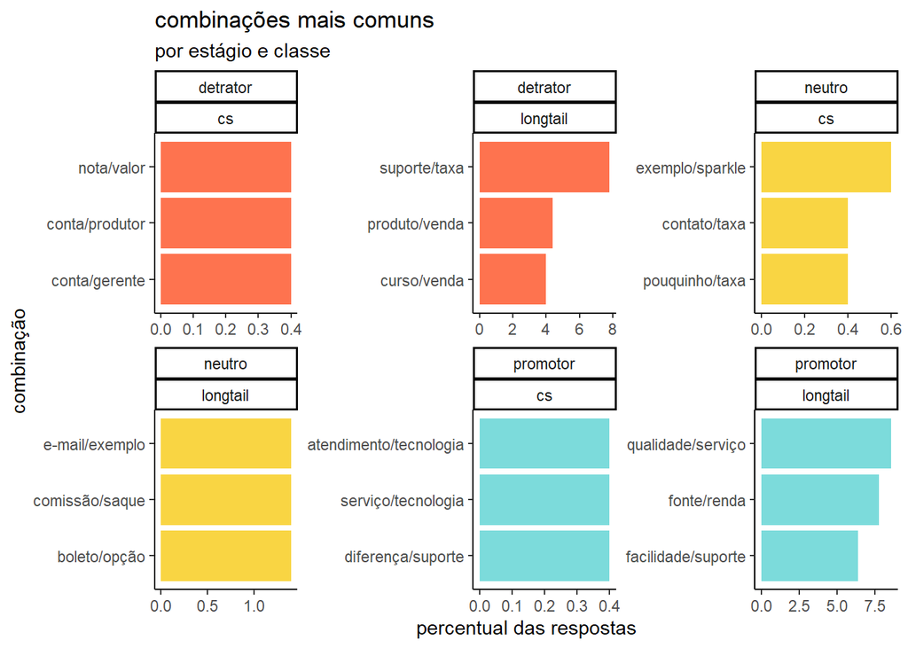

Na tabela abaixo, há um exemplo de razão para cada classe e combinação:

### CS

| classe | token | razão |
| --- | --- | --- |
| detrator | conta/gerente | Os gerentes de conta não dão assistência que o produtor precisa… a taxa cobrada é alta, no fim do processo e analise dos gastos, a plataforma fica com mais lucro que o produtor. |
| detrator | conta/produtor | Dois pontos: primeiro que o gerente de conta nunca responde aos chamados de ajuda para resolver duvidas, praticamente somos ignorados, e leve em conta que somos uma conta black com milhões em vendas. … |
| detrator | nota/valor | Nós estamos com diversos problemas deste o princípio da nossa conta. 1 - Nós tivemos produtos reavaliados e suspensos sem qualquer comunicação prévia no dia 29 de DEZEMBRO. 2 - Até o presente momento … |
| neutro | pouquinho/taxa | Pois me atende mas sinto falta de um contato via telefone para ajudar rm algumas situações. Também acho que a taxa poderia melhorar um pouquinho mais. |
| neutro | contato/taxa | Boa para iniciante, mas deixa a desejar quando você trabalha com projetos maiores. Faz 12 meses que entram em contato comigo para redução das taxas e não desenrola. |
| neutro | exemplo/sparkle | A Hotmart é a melhor experiência do usuário enquanto consumidor de conteúdo, eu mesma amo usar o sparkle para consumir meus cursos. No entanto, para o produtor, a questão financeira ainda é algo a ser… |
| promotor | diferença/suporte | Amo o atendimento do nosso suporte Nina! Da gestora Nat também, ter esse apoio faz toda a diferença! |
| promotor | serviço/tecnologia | Atendimento - Serviço - Tecnologia |
| promotor | atendimento/tecnologia | atendimento, tecnologia, suporte. |

### Longtail

| classe | token | razão |
| --- | --- | --- |
| detrator | curso/venda | Acho o prazo de 7 dias muito curto, para avaliação do meu curso de 7 horas, tem gente que compra, faz o curso inteiro em 3 dias e devolve, fala que não era o que estava procurando, pra poder firmar ve… |
| detrator | produto/venda | Contratei um especialista, onde comaçamos a fazer vendas de 2 produtos dele, ele cadastrou a consta errada, mandei e-mail para o suporte que disse que não havia possibilidade de reabrir o campo para e… |
| detrator | suporte/taxa | Integração extensões hotmart é péssima, área de membros confusa para o usuário, maior taxa do mercado, não tem suporte via chat, não tem suporte via telefone, enquanto outras plataformas oferecem chat… |
| neutro | boleto/opção | A plataforma é segura e confiável, mas existem muitas limitações com relação à formas de pagamento. Não podemos oferecer 2 formas de pagamento em planos de assinatura (ex: 2 cartões ou boleto+cartão).… |
| neutro | comissão/saque | Pq Deveria Ter Mais Rapidez Em Questoes A Saques Das Comissões |
| neutro | e-mail/exemplo | Ser informado de que fiz uma venda de meu atendimento por e-mail, com nome e endereço eletrõnico da pessoa, quanto vou receber, em que dia foi a compra é ótimo. Só é um absurdo não poder saber para qu… |
| promotor | facilidade/suporte | Por achar facil de usar, facilidades de ferramentas internas, e pela agilidade no suporte e saques na plataforma. Porém gostaria muito que a area de alunos pudesse ser mais agradavel de navegação e ma… |
| promotor | fonte/renda | Por que eu estou gostando muito da plataforma . Está me rendendo uma fonte de renda que eu não imaginava nunca que poderia acontecer |
| promotor | qualidade/serviço | Pela qualidade dos serviços prestadas pela hotmart, Além de serem atenciosos e prestativos nos atendimentos, se preocupam com os produtores, fornecendo sempre mentorias e eventos com conteúdo de quali… |

Quanto maior o número de caracteres de uma resposta (o tamanho dela), mais informação ela pode trazer. É comum que essas respostas estejam detalhando:

- Uma anedota pessoal, ou
- Sugestões mais específicas que a média.

Algumas sugestões são interessantes e podem representar possíveis soluções para as dores de seus respectivos blocos. A tabela abaixo mostra as respostas das top 3 maiores respostas por bloco:

### CS

| classe | token | razão |
| --- | --- | --- |
| detrator | 345 | Aplicativo Sparkle deixa muito a desejar! Alunos reclamando de dificuldades para acessar, dificuldades para fazer funcionar o Chromecast, tem dias que funciona tem dias que não. Já abrimos diversos ch… |
| detrator | 409 | Apesar de algumas evoluções com o Sistema, ainda há coisas em desenvolvimento e a melhorar. Há algumas questões latentes, como a falta de uma ferramenta para o envio de acesso automático para o aluno … |
| detrator | 613 | Nós estamos com diversos problemas deste o princípio da nossa conta. 1 - Nós tivemos produtos reavaliados e suspensos sem qualquer comunicação prévia no dia 29 de DEZEMBRO. 2 - Até o presente momento … |
| neutro | 535 | Em relação a plataforma vemos que ainda podem melhorar a parte de relatórios dos clientes, a área de membros ser integrada qdo o cliente compra mais de 1 produto nosso não precisar fazer acessos difer… |
| neutro | 574 | Apesar do enorme potencial da Hotmart não nos sentimos plenamente contemplados como parceiros de negócios. Os últimos três gerentes tiram férias uma semana depois que começa. A última gerente já tirou… |
| neutro | 596 | A Hotmart é a melhor experiência do usuário enquanto consumidor de conteúdo, eu mesma amo usar o sparkle para consumir meus cursos. No entanto, para o produtor, a questão financeira ainda é algo a ser… |
| promotor | 296 | O sistema de assinaturas e o hotmart club são muito inflexíveis. Estou com um problema mais de 1 ano: eu optei por assinatura anual sem recorrência e quando vendo uma assinatura ela já entra como venc… |
| promotor | 324 | Apesar de ter uma taxa negociada, ainda acredito que é alta. E que produtos com garantia de 15 dias, a comissão deveria ser paga no 16º dia. E Hotmart já deveria ser um banco digital, pelo menos de pa… |
| promotor | 326 | Acho ela boa, gosto do atendimento que tenho hoje, gosto do sparkle, e sei que é uma empresa séria. Por outro lado sei que afiliado pequeno ainda sem atendimento, acho as taxas alta, acho que tem prob… |

### Longtail

| classe | token | razão |
| --- | --- | --- |
| detrator | 1591 | Integração extensões hotmart é péssima, área de membros confusa para o usuário, maior taxa do mercado, não tem suporte via chat, não tem suporte via telefone, enquanto outras plataformas oferecem chat… |
| detrator | 2001 | Eu e minha esposa somos infoprodutores, ela com a conta Hotmart dela e eu com a minha. Ela é MEI e eu estava com minha conta cadastrada no meu CPF (já que também sou servidor público e não posso ter M… |
| detrator | 2045 | Sou jovem, tenho uma mini- empresa, Estudei Medicina na Alemanha, sou formada em terapia biográfica entre muitos outros diplomas, trabalho com terapias ONLINE antes mesmo da quarentena e tive ENORME d… |
| neutro | 1097 | Tivemos alguns problemas como: Quando criamos uma turma, temos que ir conteúdo por conteúdo para dizer qual módulo posso adicionar, ao invés de no gerenciamento da turma, poderia ter as opções de que … |
| neutro | 1175 | Principalmente pela incapacidade de afiliados estrangeiros afiliarem-se à produtos cadastrados no Brasil. Isso afecta bastante aos afiliados estrangeiros profissionais. Falo com tanta autoridade poque… |
| neutro | 1212 | Ao longo dos 5 anos que venho usando Hotmart, vi poucas evoluções na plataforma Club, que é excelente para veicular as aulas, mas possui limitações para quem enxerga o recurso potencial de ser um LMS … |
| promotor | 1397 | Por que entendo que a Hotmart, apesar de ter evoluído muito em relação aos seus Afiliados, ainda pode (no meu entendimento) agregar mais valor para os Afiliados (que é a parte mais fraca desta relação… |
| promotor | 1456 | a hotmart possibilita a escala de um produto e a transformação do produtor/afiliado, com tudo eu gostaria que a hotmart dedicasse mais esforços para App que seja similar a pagina da web, e que possibi… |
| promotor | 1487 | O limite que vocês impõem de acessos gratuitos aos infoprodutos, não me permite implementar o One-For-One (pesquisem por “one-for-one business model” no Google). Esse modelo é algo muito importante pa… |

## Futuro

Algumas sugestões de desenvolvimento:

- Analisar comportamento entre notas de transição (ex: notas 8 e 9, na transição entre neutro e promotor). Possivelmente fazer um estudo considerando a nota 8 como promotor (proposta de NPS europeu),
- Aprofundar seção *Benchmarks*.

## Referências

NPS: https://www.netpromoter.com/know/  
Benchmarks: https://www.retently.com/blog/good-net-promoter-score/  
Dataviz: https://www.promoter.io/